# R markdown main workfile

## 2.11 Line graphs

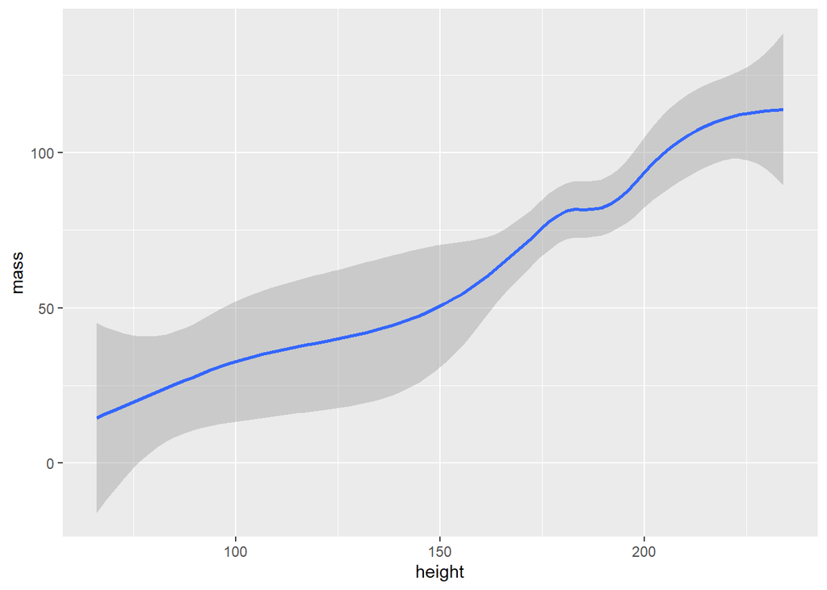

```r
starwars2 <- starwars %>%
    filter(sex %in% c("male", "female"), gender %in% c("masculine",
        "feminine"))


ggplot(starwars2, aes(x = height, y = mass)) + geom_smooth()
```

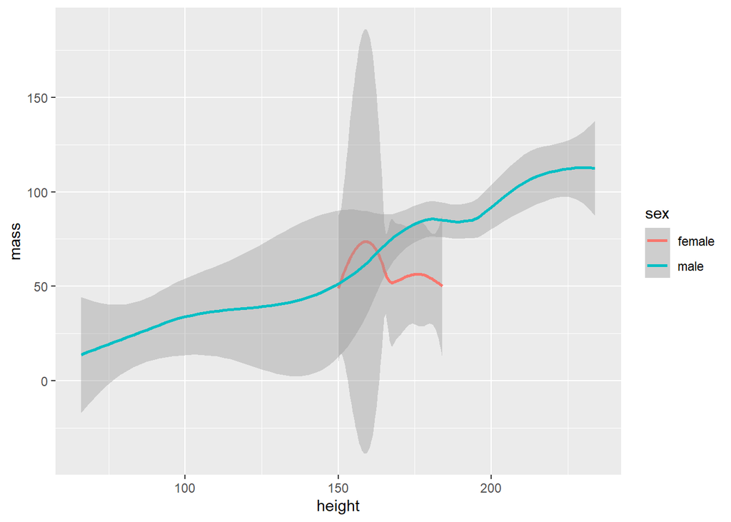

```r
ggplot(starwars2, aes(x = height, y = mass, color = sex)) + geom_smooth()
```

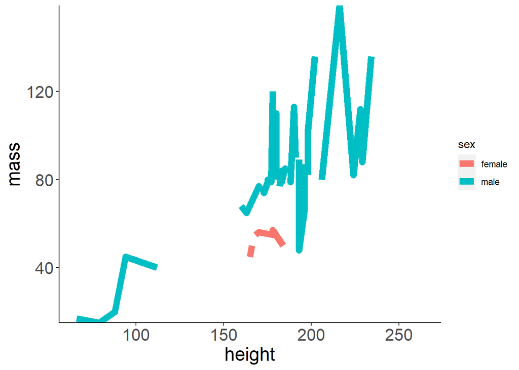

```r
ggplot(starwars2, aes(x = height, y = mass, colour = sex)) +
    geom_line(size = 3) + theme(axis.line = element_line(size = 0.5),
    panel.background = element_rect(fill = NA, size = rel(20)),
    panel.grid.minor = element_line(colour = NA), axis.text = element_text(size = 16),
    axis.title = element_text(size = 18)) + scale_y_continuous(expand = c(0,
    0))
```

```r
Orange
```

```
## Grouped Data: circumference ~ age | Tree
##    Tree  age circumference
## 1     1  118            30
## 2     1  484            58
## 3     1  664            87
## 4     1 1004           115
## 5     1 1231           120
## 6     1 1372           142
## 7     1 1582           145
## 8     2  118            33
## 9     2  484            69
## 10    2  664           111
## 11    2 1004           156
## 12    2 1231           172
## 13    2 1372           203
```

[output cut: 22 more lines]

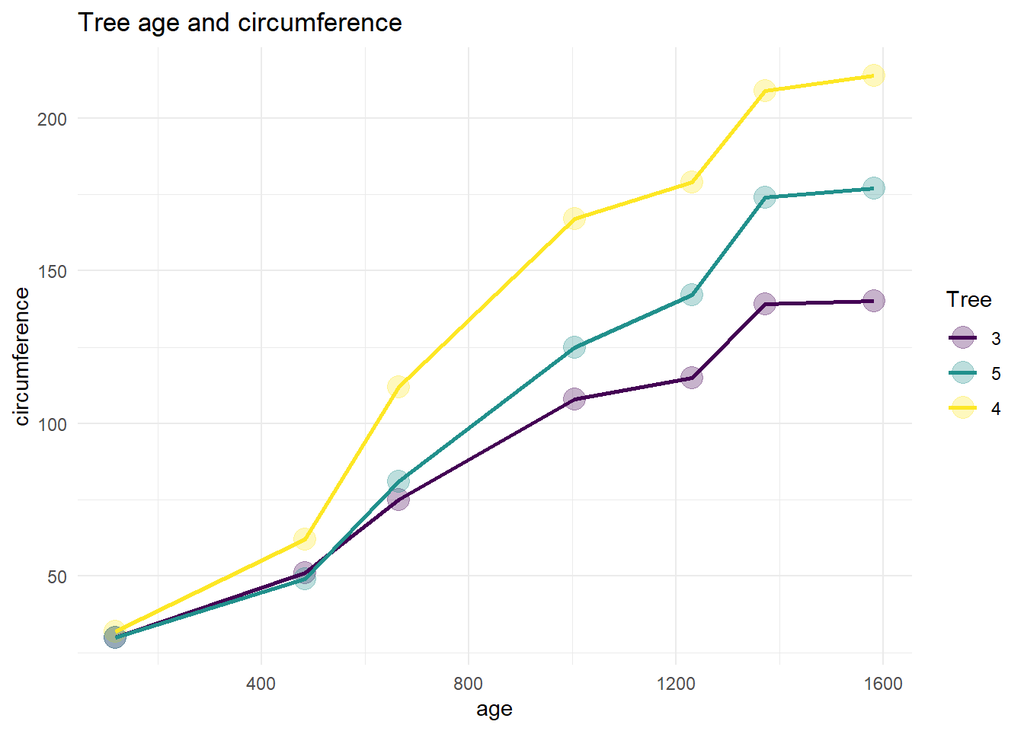

```r
Orange %>%
    filter(Tree != "1" & Tree != "2") %>%
    ggplot(aes(x = age, y = circumference, colour = Tree)) +
    geom_point(size = 5, alpha = 0.3) + geom_line(size = 1) +
    theme_minimal() + labs(title = "Tree age and circumference")
```

```r
# line graphs with error bars (SEM) + customly-coloured
# SEM, mean, custom colours
library(ggplot2)

sem <- function(x, na.rm = FALSE) {
    out <- sd(x, na.rm = na.rm)/sqrt(length(x))
    return(out)
}
pointcolour <- c(Fair = "yellow", Good = "red", `Very Good` = "pink",
    Premium = "blue", Ideal = "black")
# write.csv(diamonds, file='diamonds.csv', row.names=TRUE)
```

## 2.12 Pie charts

Nothing here right now…

## 2.13 Tiered faceted graphs

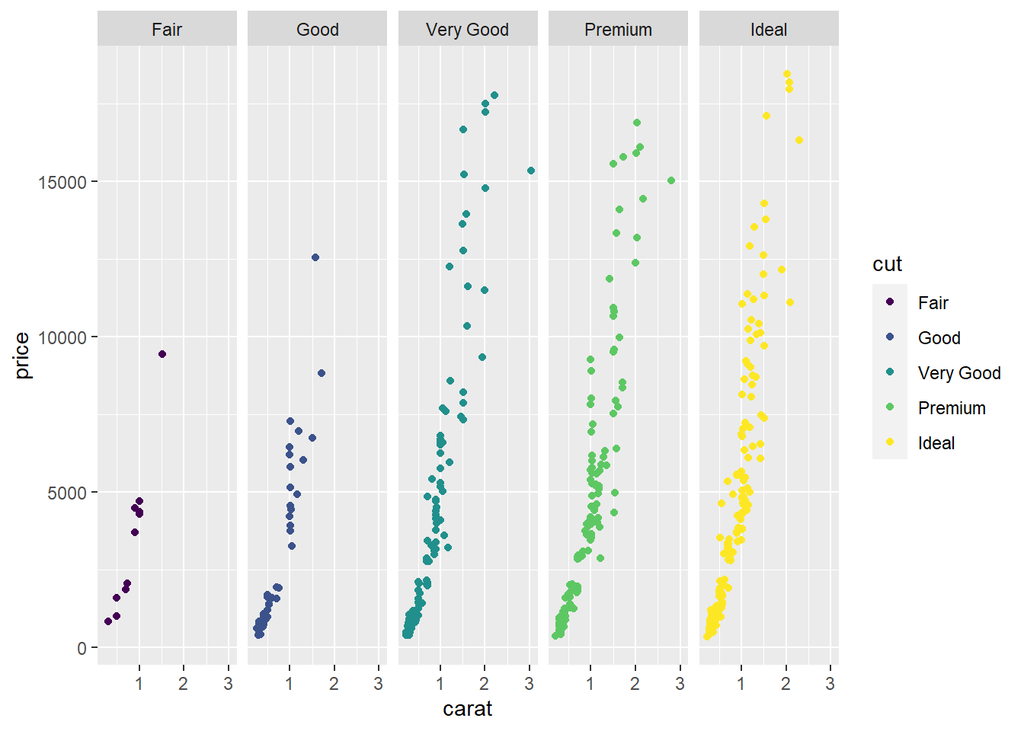

```r
library(ggpubr)

p1 <- ggplot(diamonds[seq(1, 50000, by = 100),], aes(x = carat, y = price, colour = cut)) + geom_point() + facet_wrap( ~ cut, nrow = 1)
p1
```

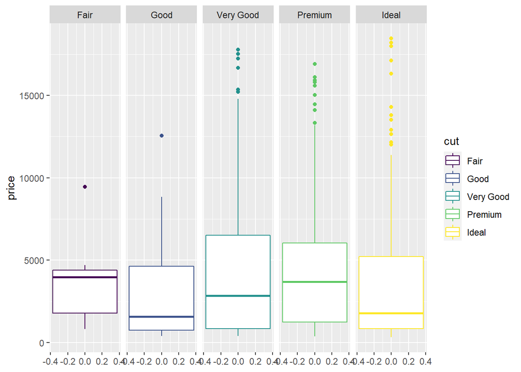

```r
p2 <- ggplot(diamonds[seq(1, 50000, by = 100),], aes(y = price, colour = cut)) + geom_boxplot() + facet_wrap( ~ cut, nrow = 1) # can add argument scale = "free_x" to make it automatically scaled
p2
```

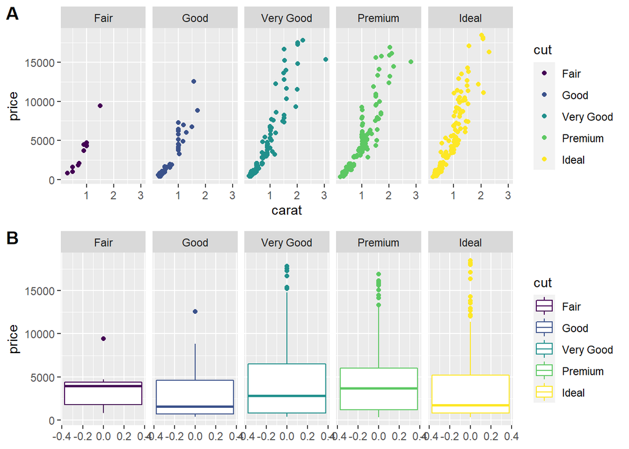

```r
ggarrange(p1, p2, nrow = 2, labels = "AUTO")
```

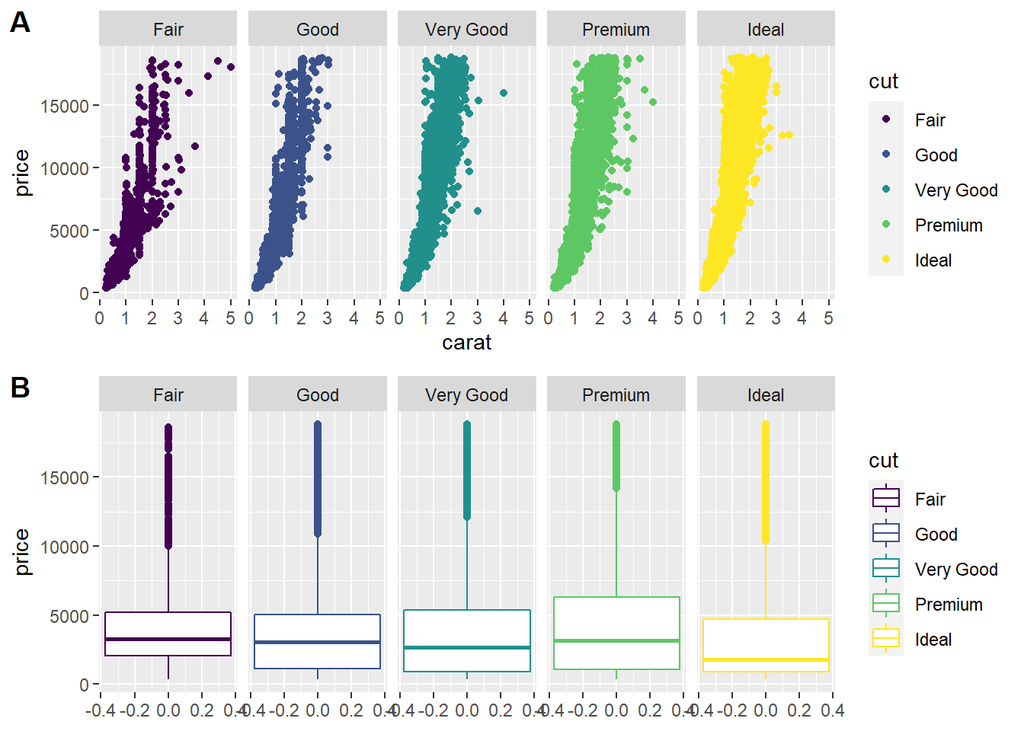

```r
# OR the same, just the entire dataset & without creating new variables #
ggarrange(
  # graph 1
  ggplot(diamonds, aes(x = carat, y = price, colour = cut)) + geom_point() + facet_wrap( ~ cut, nrow = 1),
  # graph 2
  ggplot(diamonds, aes(y = price, colour = cut)) + geom_boxplot() + facet_wrap( ~ cut, nrow = 1),
  # ggarrange settings
  nrow = 2, labels = "AUTO"
)
```

```r
summary(relig_income)
```

[output not shown]

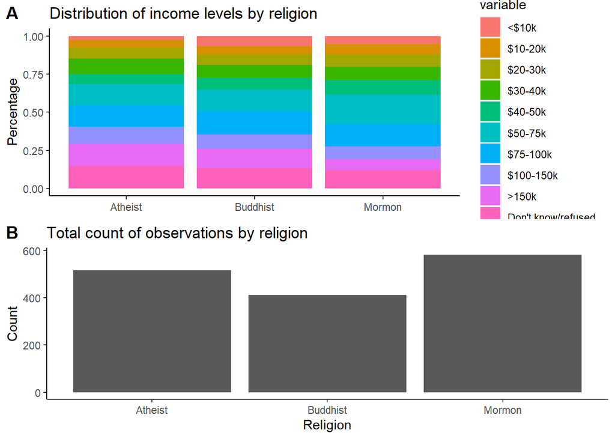

```r
p1 <- relig_income %>%
  filter(religion == "Atheist" |
           religion == "Mormon" |
           religion == "Buddhist") %>%
  melt(id.vars = "religion") %>%
  group_by(religion, variable) %>%
  ggplot(aes(x = religion, y = value, fill = variable)) +
  geom_bar(stat="identity", position = "fill") +
  theme(panel.grid.major = element_blank(),
        panel.grid.minor = element_blank(),
        axis.title.x = element_blank(),
        panel.background = element_blank(),
        axis.line = element_line(size = 0.5)) +
  scale_color_brewer(palette = "Set1") +
  labs(title = "Distribution of income levels by religion",
       y = "Percentage")
p2 <- relig_income %>%
  filter(religion == "Atheist" |
           religion == "Mormon" |
           religion == "Buddhist") %>%
  melt(id.vars = "religion") %>%
  group_by(religion, variable) %>%
  ggplot(aes(x = religion, y = value)) +
  geom_bar(stat="identity") +
  theme(panel.grid.major = element_blank(),
        panel.grid.minor = element_blank(),
        axis.title = element_text(),
        panel.background = element_blank(),
        axis.line = element_line(size = 0.5)) +
  scale_color_brewer(palette = "Set1") +
  labs(title = "Total count of observations by religion",
       x = "Religion",
       y = "Count")
ggarrange(p1, p2, nrow = 2, labels = "AUTO")
```

# 3 Graph customisation

## 3.1 Theme settings

- Flip coordinates: + coord_flip()
- Log scale: + scale_y_log10()
- Show fonts: fonts()
- Globally change theme settings: theme_set(theme_gray(base_size=20))

## 3.2 Colour changes

- Globally reset theme settings to default: theme_set(theme_gray())
- Black and white theme: mainplot + theme_bw()
- Manually assign colours: scale_color_manual(values = c(“#A6611A”, “#DFC27D”, “#6e6c6b”, “#80CDC1”, “#018571”))

## 3.3 Colour palettes

- library(RColorBrewer)
- display.brewer.all()
- colours() # gives names of different colours
- mainplot + scale_fill_brewer(palette=“Set1”)
- Setting colour values for each of the 5 variables in my mainplot graph manually: mainplot + scale_fill_manual(values = c(“green”, “blue”, “red”, “orange”, “grey”))

## 3.4 Changing theme

`+ theme()` argument

- Number size on axis: axis.text = element_text(size = 20)
- Title size on axis: axis.title = element_text(size = 20)
- Legend: legend.title = element_text(size = 20)
- Background: panel.background = element_rect(fill = “pink”)
- Change major gridlines: panel.grid.major = element_line(colour = “blue”)
  - size = 0.2
  - NA
- Change minor gridlines: panel.grid.minor = element_line(colour = “red”)
- Change tick marks: axis.ticks = element_line(size=2, colour=“blue”)
  - As options: axis.ticks.x, axis.ticks.y
- Change legend position: legend.position=“top”
  - Other arguments:
  - “bottom”
  - Bottom left: c(0,0)
  - Near the top right: c(0.8,0.8)

## 3.5 Changing labels

`+ labs()` argument

- title = “Title”
- y = “Title y”
- x = “Title x”

## 3.6 Publication style

Clear background, axis lines, no box, no grid lines, basic colors, no legend

```r
# Just for one plot
mainplot + theme(axis.line = element_line(size = 0.5), panel.background = element_rect(fill = NA,
    size = rel(20)), panel.grid.minor = element_line(colour = NA),
    axis.text = element_text(size = 16), axis.title = element_text(size = 18)) +
    scale_y_continuous(expand = c(0, 0))  # to stop the bars from floaing above the x-axis

# Globally apply this theme
theme_set(theme_gray() + theme(axis.line = element_line(size = 0.5),
    panel.background = element_rect(fill = NA, size = rel(20)),
    panel.grid.minor = element_line(colour = NA), axis.text = element_text(size = 16),
    axis.title = element_text(size = 18)))
```